# PCFL 2021: Week 12 wrap-up

Countdown to the playoffs! Only **THREE** weeks to go.

### Last week’s games

| Away | Away points | Home | Home points | Predicted result |
| --- | --- | --- | --- | --- |
| Pigskin on the Gridiron | 123.88 | Middle Earth Hangry Hobbits | 91.35 | Pigskin on the Gridiron (+12.23) |
| KC Gophers | 92.10 | The Sophomores TSoph | 105.38 | The Sophomores TSoph (+46.33) |
| Captain Clairvoyant | 101.74 | Jumpin’ Jaheims | 107.70 | Captain Clairvoyant (+28.29) |
| Georgia Peanuts | 84.42 | Southern Sharks | 70.86 | Georgia Peanuts (+4.23) |
| The G.O.A.T. | 96.30 | Athens Team Sasquatch | 128.60 | The G.O.A.T. (+3.02) |

Last week’s game of the week was Gophers vs. Sophomores, with the latter favored by 46(!) points. It wasn’t a nail biter, but the Sophomore’s winning margin of 13 seems much slimmer when considering that the Gophers had two starters on bye. Could have been an upset!

#### Best performing players

Here’s last week’s **10 best performing players.**

| Player | Points | Team |
| --- | --- | --- |
| Leonard Fournette | 40.60 | Pigskin on the Gridiron |
| Joe Mixon | 30.30 | The Sophomores TSoph |
| Josh Allen | 26.70 | Athens Team Sasquatch |
| Cordarrelle Patterson | 26.50 | Athens Team Sasquatch |
| Aaron Rodgers | 26.28 | The Sophomores TSoph |
| Elijah Mitchell | 25.30 | Georgia Peanuts |
| Dak Prescott | 25.30 | The G.O.A.T. |
| Jaylen Waddle | 24.55 | Middle Earth Hangry Hobbits |
| Matthew Stafford | 21.98 | Middle Earth Hangry Hobbits |
| Mac Jones | 21.50 | Captain Clairvoyant |

A great week for running backs: Leonard Fournette and Joe Mixon both did well. And after three teams, something finally has clicked for Cordarrelle Patterson in Atlanta.

#### Best addition and top bench

There were 13 players added last week. Which was the **best new addition**?

| Date added | Name | Points | Team |
| --- | --- | --- | --- |
| 2021-11-24 | Dontrell Hilliard | 19.90 | Pigskin on the Gridiron |
| 2021-11-24 | Odell Beckham Jr. | 17.60 | Athens Team Sasquatch |
| 2021-11-24 | Cedrick Wilson | 14.70 | Athens Team Sasquatch |
| 2021-11-24 | Texans D/ST | 8.00 | Athens Team Sasquatch |
| 2021-11-25 | Cole Beasley | 7.10 | Athens Team Sasquatch |
| 2021-11-25 | Tyler Bass | 7.00 | Captain Clairvoyant |
| 2021-11-24 | David Johnson | 6.50 | Athens Team Sasquatch |
| 2021-11-24 | Cam Newton | 6.18 | Georgia Peanuts |
| 2021-11-24 | Bears D/ST | 6.00 | Southern Sharks |
| 2021-11-27 | Ty Johnson | 4.20 | Southern Sharks |
| 2021-11-25 | Lions D/ST | 3.00 | Middle Earth Hangry Hobbits |
| 2021-11-25 | Tony Jones Jr. | 2.70 | Athens Team Sasquatch |
| 2021-11-24 | Kadarius Toney | 0.00 | Captain Clairvoyant |

I considered OBJ for a bit, but figured the glory days were behind him. Kudos to Robbie for giving him a chance. Dontrell Hilliard also did a nice job as the most recent RB to try to replace Derrick Henry in Tennessee.

Who won the **best scoring bench** award last week?

| Team | Points |
| --- | --- |
| Pigskin on the Gridiron | 98.50 |
| Georgia Peanuts | 80.28 |
| Middle Earth Hangry Hobbits | 65.86 |
| Athens Team Sasquatch | 59.70 |
| KC Gophers | 55.58 |
| The G.O.A.T. | 47.86 |
| The Sophomores TSoph | 47.22 |
| Southern Sharks | 40.97 |
| Jumpin’ Jaheims | 38.72 |
| Captain Clairvoyant | 34.05 |

Who has the most bench points for the *season*? Here’s the current standings:

| Team name | Total bench points |
| --- | --- |
| Southern Sharks | 958.49 |
| Middle Earth Hangry Hobbits | 880.61 |
| Athens Team Sasquatch | 840.23 |
| Pigskin on the Gridiron | 818.26 |
| The Sophomores TSoph | 799.32 |
| Jumpin’ Jaheims | 699.84 |
| KC Gophers | 696.72 |
| Captain Clairvoyant | 687.83 |
| Georgia Peanuts | 632.45 |
| The G.O.A.T. | 617.95 |

Sarah remains in the lead, but Scott’s slowly creeping up on that top spot.

### League standings and season stats

Here’s a look at the current standings.

| Team | Division | W | L | Points scored | Points allowed | Points rank | Playoff rank |
| --- | --- | --- | --- | --- | --- | --- | --- |
| The Sophomores TSoph | Hot Dish | 10 | 2 | 1443.32 | 1278.14 | 1 | 1 |
| Athens Team Sasquatch | Grits | 8 | 4 | 1415.60 | 1342.89 | 2 | 2 |
| Captain Clairvoyant | Grits | 8 | 4 | 1377.32 | 1246.37 | 3 | 3 |
| Pigskin on the Gridiron | Grits | 7 | 5 | 1359.09 | 1286.08 | 4 | 4 |
| Georgia Peanuts | Hot Dish | 7 | 5 | 1300.34 | 1246.64 | 6 | 5 |
| Jumpin’ Jaheims | Grits | 6 | 6 | 1245.95 | 1333.80 | 8 | 6 |
| Middle Earth Hangry Hobbits | Hot Dish | 5 | 7 | 1289.43 | 1293.07 | 7 | 7 |
| Southern Sharks | Hot Dish | 4 | 8 | 1321.30 | 1349.06 | 5 | 8 |
| The G.O.A.T. | Grits | 3 | 9 | 1131.70 | 1276.95 | 9 | 9 |
| KC Gophers | Hot Dish | 2 | 10 | 1097.20 | 1328.25 | 10 | 10 |

Here’s a list of the **top five scoring performances** so far this season.

| Team | Week | Points scored | Result |
| --- | --- | --- | --- |
| Georgia Peanuts | 5 | 158.97 | W |
| The Sophomores TSoph | 4 | 158.62 | W |
| The Sophomores TSoph | 11 | 152.50 | W |
| Athens Team Sasquatch | 5 | 149.80 | W |
| The G.O.A.T. | 4 | 149.52 | W |

Nothing to see here.

### Here’s a look at the **points trendline** for each team.

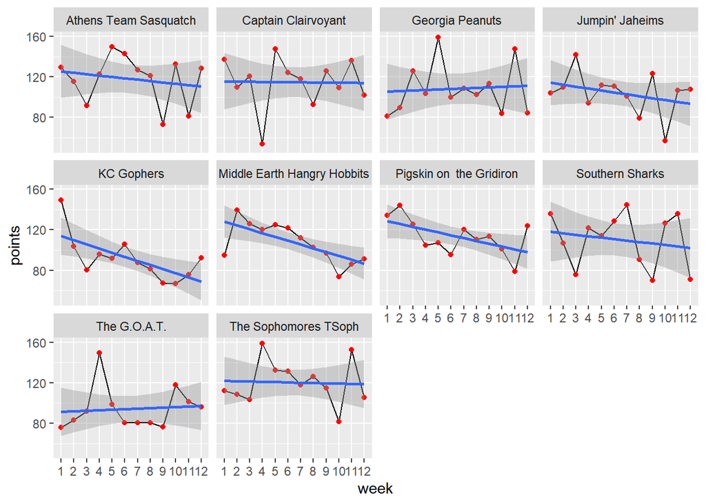

Y’all can try to make sense of this at this point. A lot of ups and downs in recent weeks.

Here’s the points trend for *all* teams by week

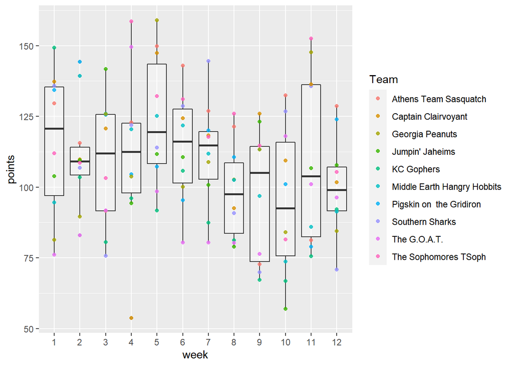

Another down week this week–third lowest median score of the season.

### If the season ended today…

Things are just coming into focus. Erin and Trav pretty much have a lock on a playoff spot. They’d have to lose out AND Richard or I would have to win out AND score about 100 more points over just three weeks. Not gonna happen. The other teams today would be Robbie, Brian and Richard. But I’m tied for that last playoff spot by record, and Evan is just one game out with three to go.

### Next week’s preview

| Away team | Last 3 wks avg (away) | Home team | Last 3 wks avg (home) | Line |
| --- | --- | --- | --- | --- |
| Captain Clairvoyant | 115.84 | The Sophomores TSoph | 113.11 | Captain Clairvoyant (+2.73) |
| Southern Sharks | 111.09 | Middle Earth Hangry Hobbits | 83.68 | Southern Sharks (+27.41) |
| Pigskin on the Gridiron | 101.28 | The G.O.A.T. | 105.13 | The G.O.A.T. (+3.85) |
| Georgia Peanuts | 105.37 | KC Gophers | 78.15 | Georgia Peanuts (+27.22) |
| Jumpin’ Jaheims | 90.47 | Athens Team Sasquatch | 114.10 | Athens Team Sasquatch (+23.63) |

This week’s game of the week is Brian vs. Erin and Trav in a battle of playoff contenders. Brian needs a win to stay in the mix, with the Sophomores can clinch their first playoff appearance with a victory. Sarah and Scott are both long shots for the playoffs, but their game this week could end one of their seasons. Another battle for the Pages this week, with Richard facing Jacob. In other action, Robbie faces Evan, and I’m up against Christine.

Good luck, y’all! (And remember to check your byes!)